# Project 2 Data Exploration

2024-03-11

Load packages (R):

```r
library(tidyverse) #for data visualization and manipulation:
library(tidymodels)
library(caret)
```

```r
library(patchwork) #to combine plots
```

Load packages (python):

```r
library(reticulate) #interfaces with Python
#conda_create("r-reticulate", conda = "C:/Users/becca/miniconda3/Scripts/conda.exe") #install & load python from my computer
use_condaenv("r-reticulate", conda = "C:/Users/becca/miniconda3/Scripts/conda.exe")
#py_install(packages = c("pandas", "scikit-learn")) #install and then load relevant Python libraries:
pd <- import("pandas")
sklearn <- import("sklearn")
np <- import("numpy")
```

Load data

```r
train <- read_csv("D:/Machine Learning/Project 2/train.csv")
train$Status <- factor(train$Status)
summary(train)
```

```
##        id           N_Days         Drug                Age
##  Min.   :   0   Min.   :  41   Length:7905        Min.   : 9598
##  1st Qu.:1976   1st Qu.:1230   Class :character   1st Qu.:15574
##  Median :3952   Median :1831   Mode  :character   Median :18713
##  Mean   :3952   Mean   :2030                      Mean   :18373
##  3rd Qu.:5928   3rd Qu.:2689                      3rd Qu.:20684
##  Max.   :7904   Max.   :4795                      Max.   :28650
##      Sex              Ascites          Hepatomegaly         Spiders
##  Length:7905        Length:7905        Length:7905        Length:7905
##  Class :character   Class :character   Class :character   Class :character
##  Mode  :character   Mode  :character   Mode  :character   Mode  :character
##
##
##
##     Edema             Bilirubin       Cholesterol        Albumin
##  Length:7905        Min.   : 0.300   Min.   : 120.0   Min.   :1.960
##  Class :character   1st Qu.: 0.700   1st Qu.: 248.0   1st Qu.:3.350
##  Mode  :character   Median : 1.100   Median : 298.0   Median :3.580
##                     Mean   : 2.594   Mean   : 350.6   Mean   :3.548
##                     3rd Qu.: 3.000   3rd Qu.: 390.0   3rd Qu.:3.770
##                     Max.   :28.000   Max.   :1775.0   Max.   :4.640
##      Copper         Alk_Phos          SGOT        Tryglicerides
##  Min.   :  4.0   Min.   :  289   Min.   : 26.35   Min.   : 33.0
##  1st Qu.: 39.0   1st Qu.:  834   1st Qu.: 75.95   1st Qu.: 84.0
##  Median : 63.0   Median : 1181   Median :108.50   Median :104.0
##  Mean   : 83.9   Mean   : 1817   Mean   :114.60   Mean   :115.3
##  3rd Qu.:102.0   3rd Qu.: 1857   3rd Qu.:137.95   3rd Qu.:139.0
##  Max.   :588.0   Max.   :13862   Max.   :457.25   Max.   :598.0
##    Platelets      Prothrombin        Stage       Status
##  Min.   : 62.0   Min.   : 9.00   Min.   :1.000   C :4965
##  1st Qu.:211.0   1st Qu.:10.00   1st Qu.:2.000   CL: 275
##  Median :265.0   Median :10.60   Median :3.000   D :2665
##  Mean   :265.2   Mean   :10.63   Mean   :3.033
##  3rd Qu.:316.0   3rd Qu.:11.00   3rd Qu.:4.000
##  Max.   :563.0   Max.   :18.00   Max.   :4.000
```

• explore the structure of the data and correlations between features • bar/column plots for categorical variables and histograms for continuous

```r
status_plot <- ggplot(train) +
  geom_bar(aes(x = Status), fill = "#D81B60", alpha = 0.75) +
  ggtitle("A")
```

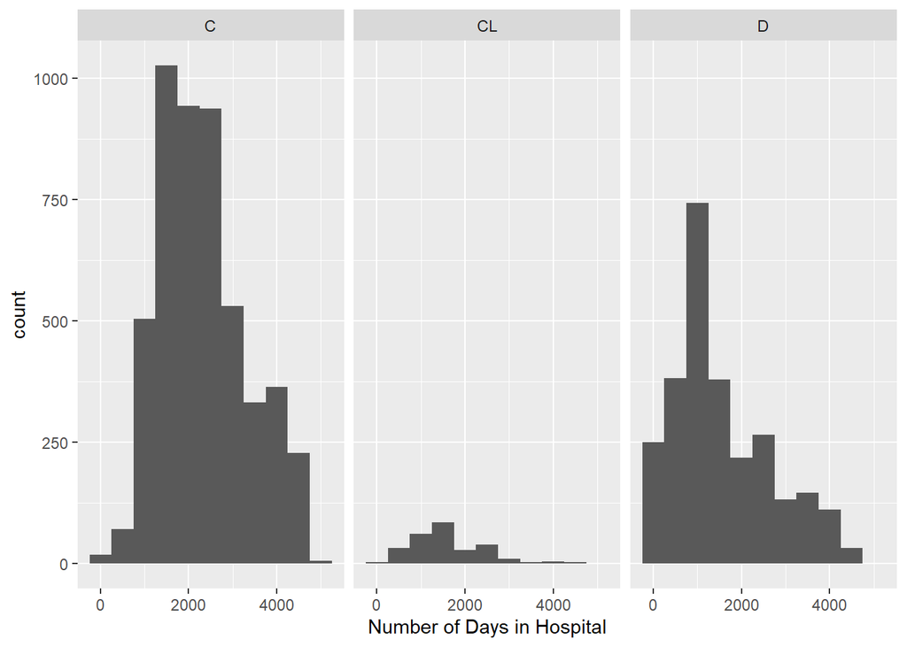

```r
ggplot(train) +
  geom_histogram(aes(x = N_Days), binwidth = 500) +
  labs(x = "Number of Days in Hospital") +
  facet_wrap(~Status)
```

```r
drug_plot <- ggplot(train) +
  geom_bar(aes(x = Status, fill = factor(Drug)), position = "fill", alpha = 0.75) +
  #fill = Drug and position = fill set it so the bars have a height of 1 with sections colored according to the relative proportion of each Drug type per status
  scale_fill_manual(values = c("#D81B60", "#1E88E5")) +
  labs(y = "Proportion of class members", x = "Outcome/status class", fill = "Drug") +
  ggtitle("B")
```

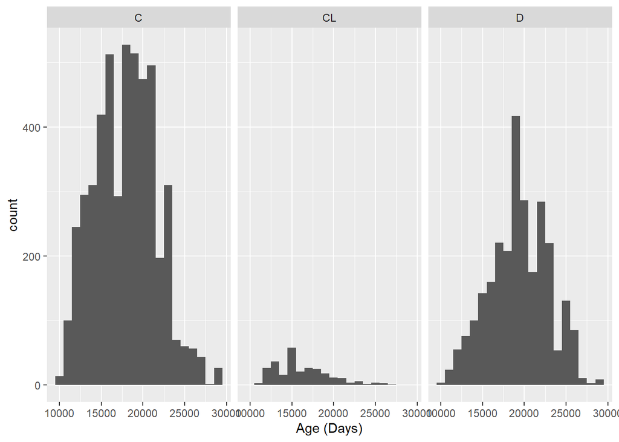

```r
ggplot(train) +
  geom_histogram(aes(x = Age), binwidth = 1000) +
  labs(x = "Age (Days)") +
  facet_wrap(~Status)
```

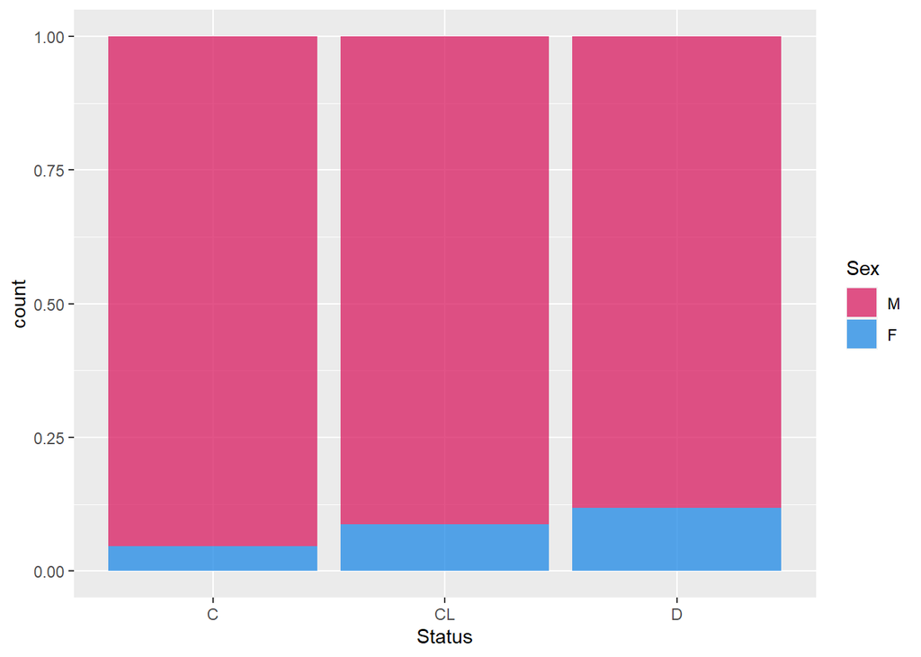

```r
ggplot(train) +
  geom_bar(aes(x = Status, fill = factor(Sex)), position = "fill", alpha = 0.75) +
  scale_fill_manual(values = c("#D81B60", "#1E88E5"), labels = unique(factor(train$Sex))) +
  labs(fill = "Sex")
```

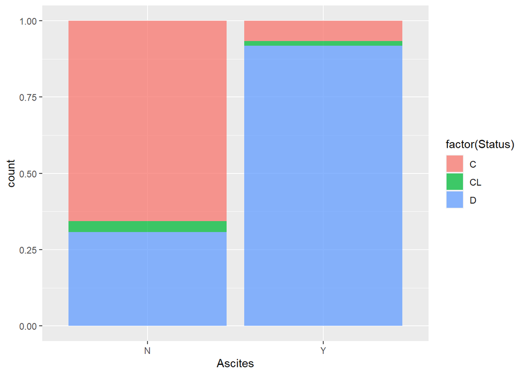

```r
ggplot(train) +
  geom_bar(aes(x = Ascites, fill = factor(Status)), position = "fill", alpha = 0.75)
```

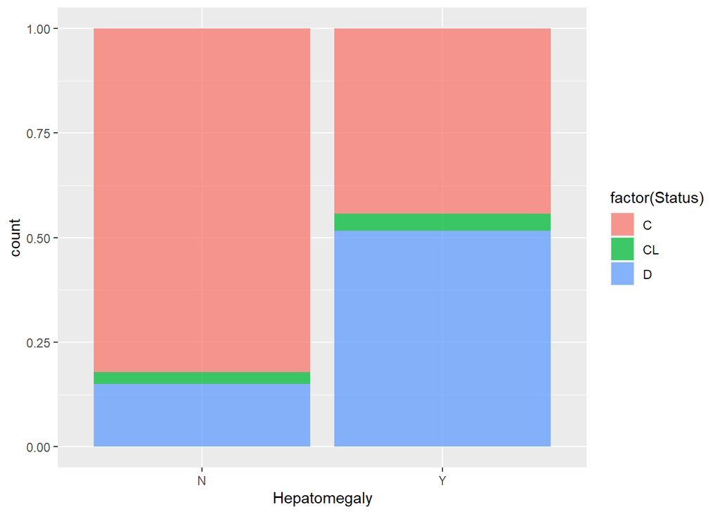

```r
ggplot(train) +
  geom_bar(aes(x = Hepatomegaly, fill = factor(Status)), position = "fill", alpha = 0.75)
```

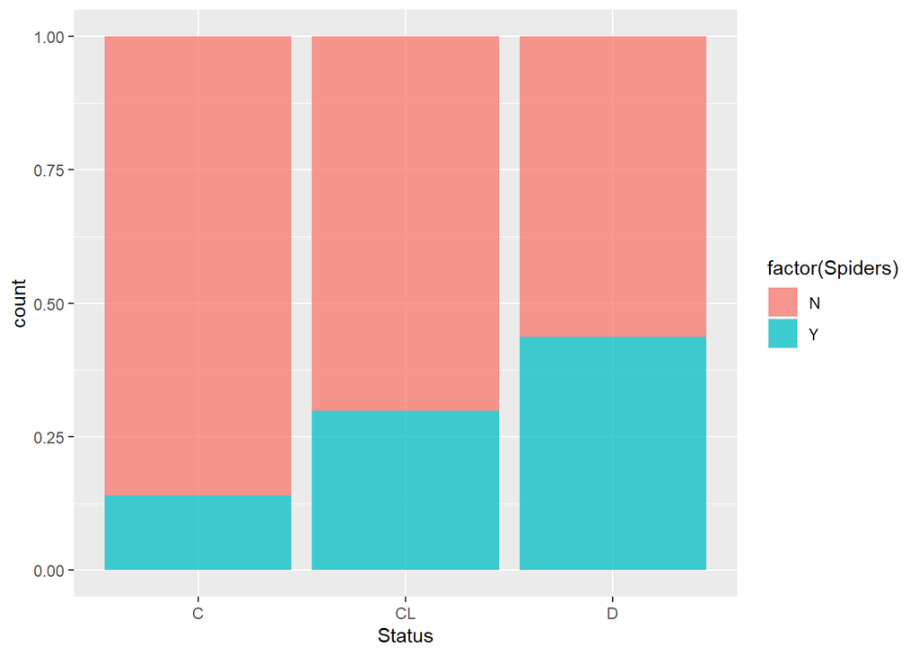

```r
ggplot(train) +
  geom_bar(aes(x = Status, fill = factor(Spiders)), position = "fill", alpha = 0.75)
```

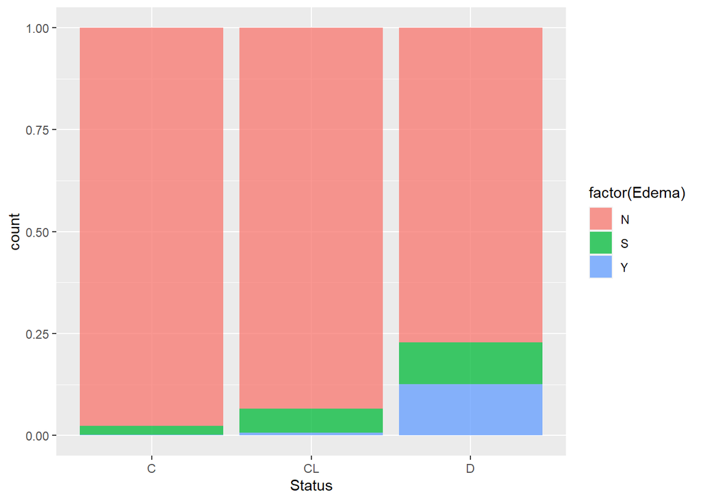

```r
ggplot(train) +
  geom_bar(aes(x = Status, fill = factor(Edema)), position = "fill", alpha = 0.75)
```

```r
bilirubin_plot <- ggplot(train) +
  geom_histogram(aes(x = Bilirubin, fill = factor(Status)), position = "fill", alpha = 0.75, binwidth = 2) +
  scale_fill_manual(values = c("#D81B60", "#1E88E5", "#FFC107")) +
  labs(y = "Proportion of each class", fill = "Outcome/status class") +
  ggtitle("C")
```

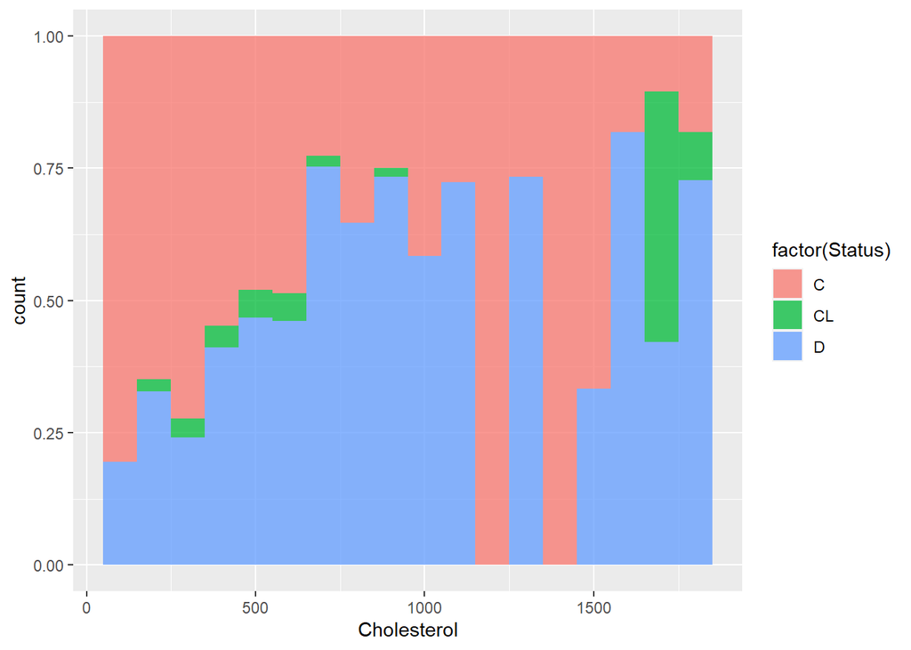

```r
ggplot(train) +
  geom_histogram(aes(x = Cholesterol, fill = factor(Status)), position = "fill", alpha = 0.75, binwidth = 100)
```

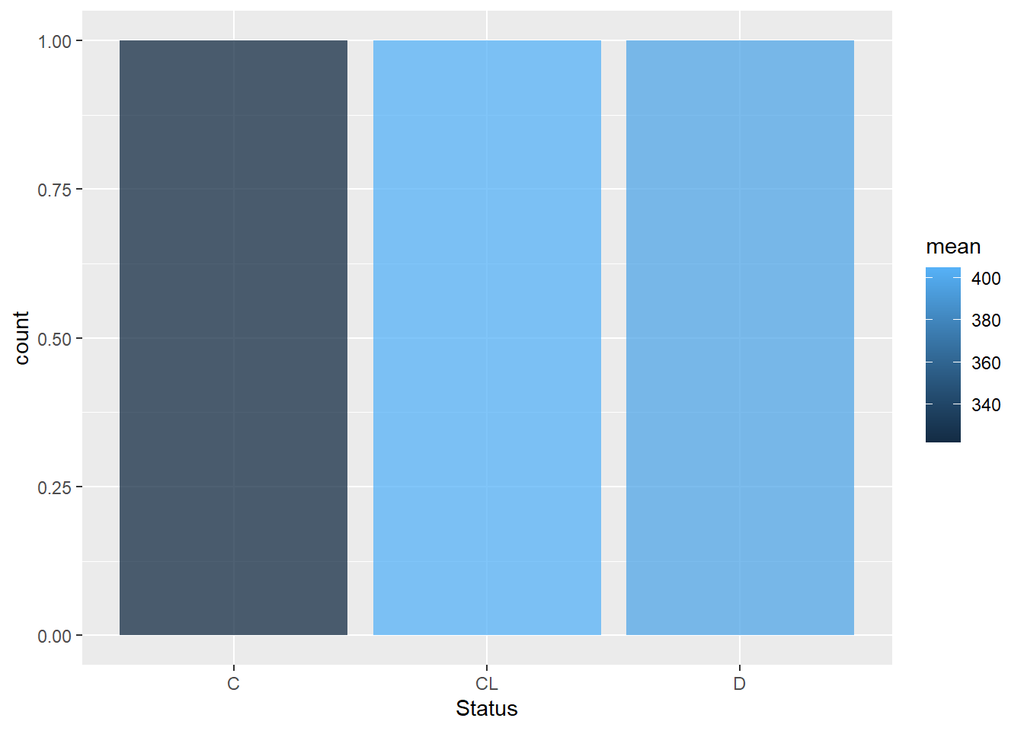

```r
train |>
  group_by(Status) |>
  summarize(
    mean = mean(Cholesterol)
  ) |>
ggplot() +
  geom_bar(aes(x = Status, fill = mean), alpha = 0.75)
```

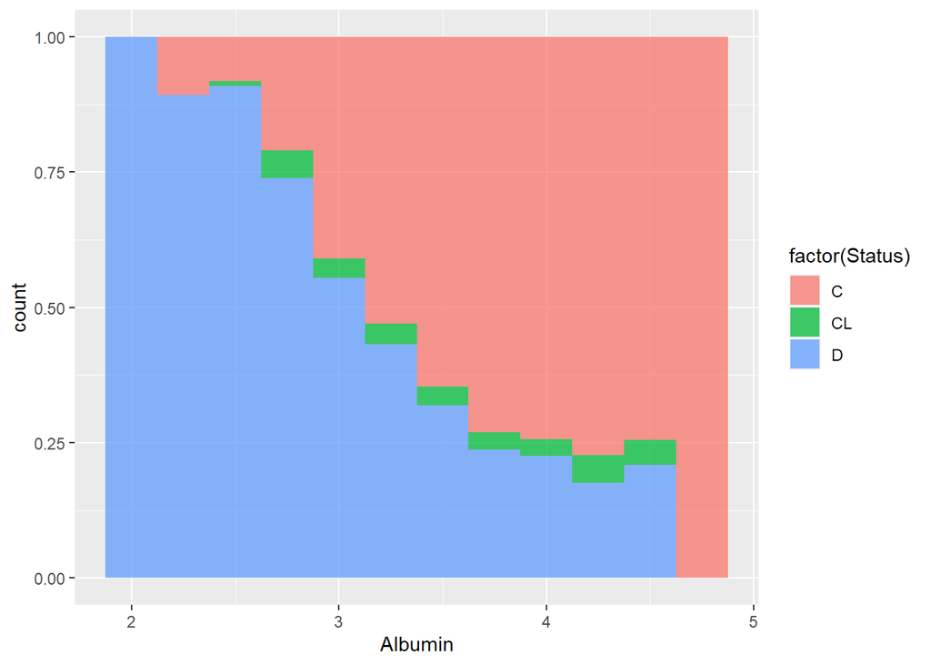

```r
ggplot(train) +
  geom_histogram(aes(x = Albumin, fill = factor(Status)), position = "fill", alpha = 0.75, binwidth = 0.25)
```

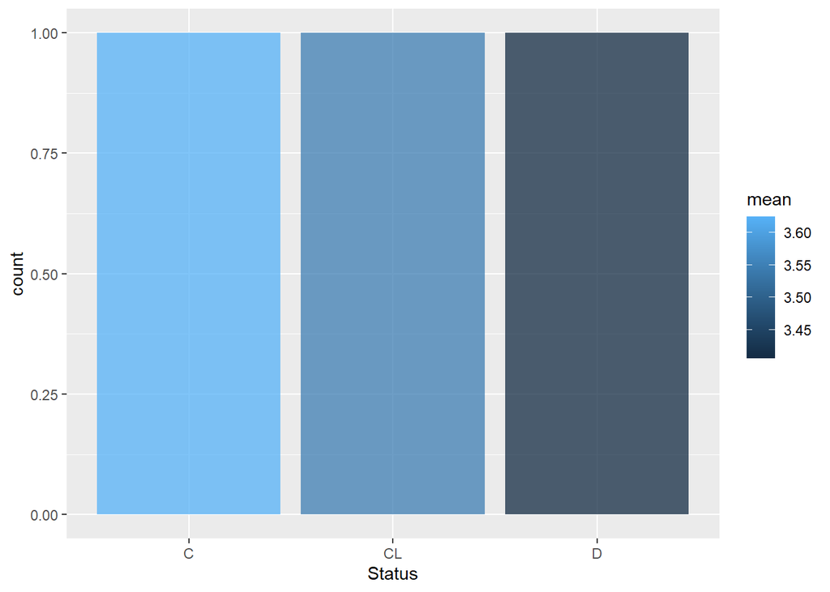

```r
train |>
  group_by(Status) |>
  summarize(
    mean = mean(Albumin)
  ) |>
ggplot() +
  geom_bar(aes(x = Status, fill = mean), alpha = 0.75)
```

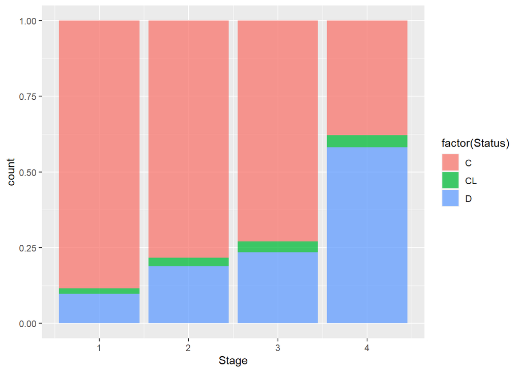

```r
ggplot(train) +
  geom_bar(aes(x = Stage, fill = factor(Status)), position = "fill", alpha = 0.75)
```

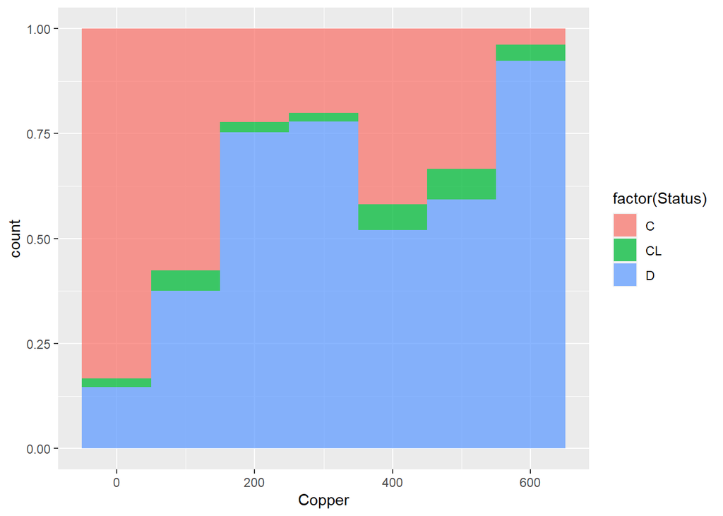

```r
ggplot(train) +
  geom_histogram(aes(x = Copper, fill = factor(Status)), position = "fill", alpha = 0.75, binwidth = 100)
```

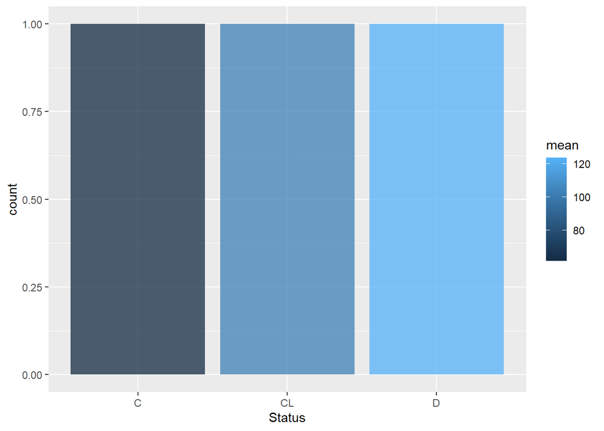

```r
train |>
  group_by(Status) |>
  summarize(
    mean = mean(Copper)
  ) |>
ggplot() +
  geom_bar(aes(x = Status, fill = mean), alpha = 0.75)
```

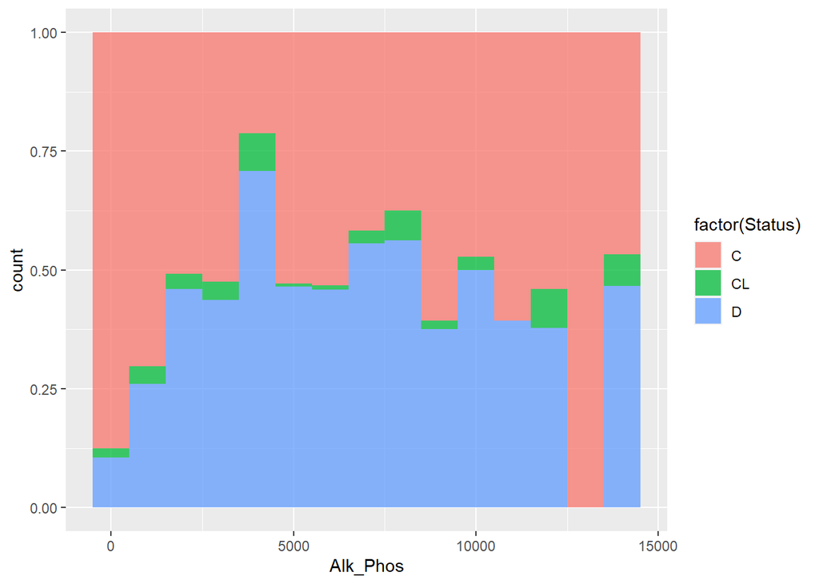

```r
ggplot(train) +
  geom_histogram(aes(x = Alk_Phos, fill = factor(Status)), position = "fill", alpha = 0.75, binwidth = 1000)
```

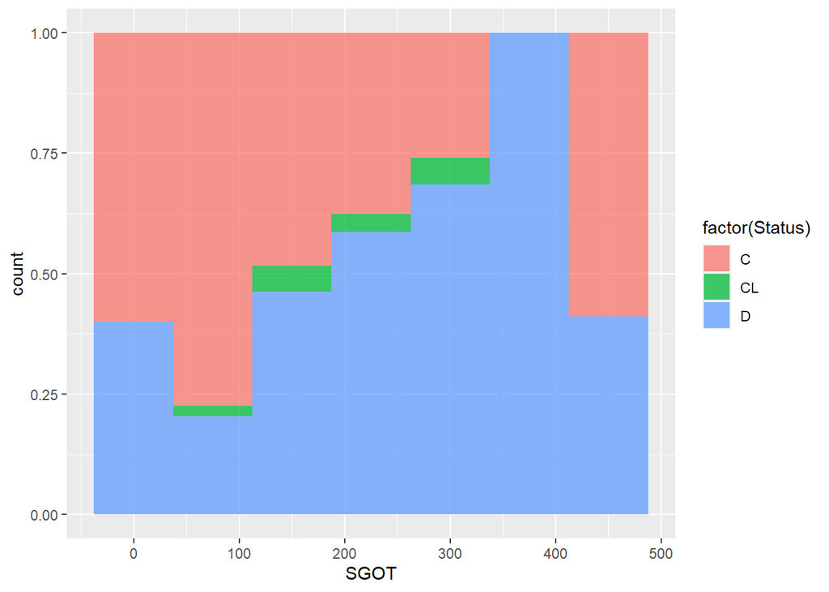

```r
ggplot(train) +
  geom_histogram(aes(x = SGOT, fill = factor(Status)), position = "fill", alpha = 0.75, binwidth = 75)
```

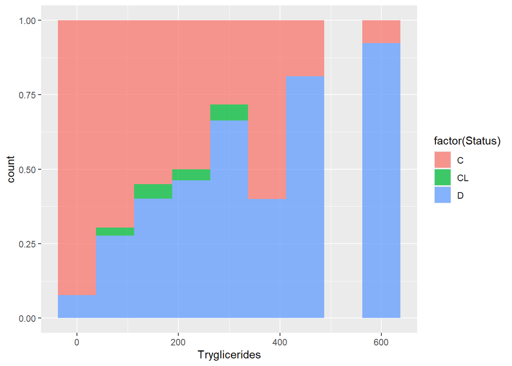

```r
ggplot(train) +
  geom_histogram(aes(x = Tryglicerides, fill = factor(Status)), position = "fill", alpha = 0.75, binwidth = 75)
```

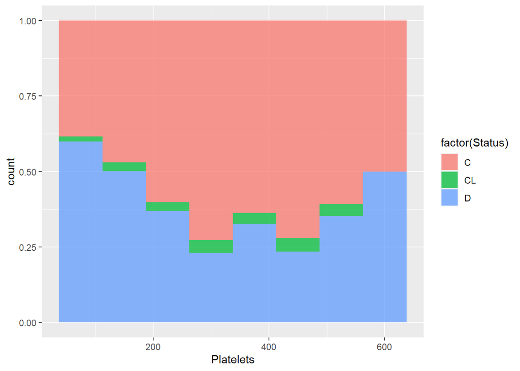

```r
ggplot(train) +
  geom_histogram(aes(x = Platelets, fill = factor(Status)), position = "fill", alpha = 0.75, binwidth = 75)
```

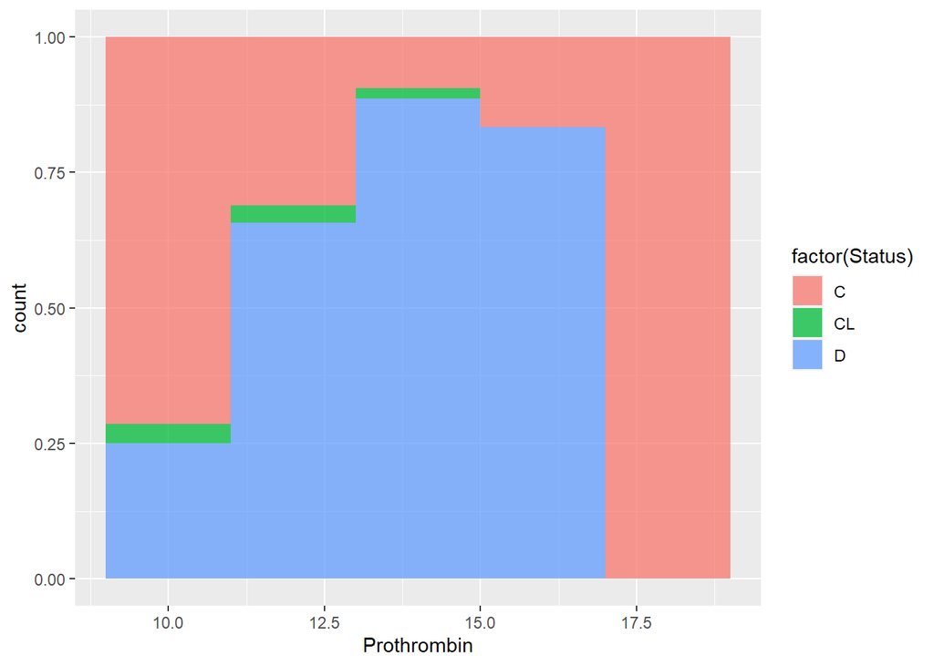

```r
ggplot(train) +
  geom_histogram(aes(x = Prothrombin, fill = factor(Status)), position = "fill", alpha = 0.75, binwidth = 2)
```

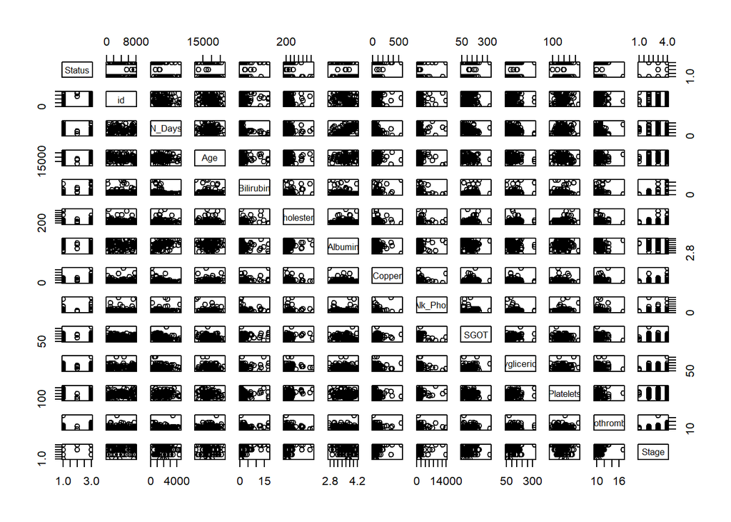

```r
train_num <- train |>
  select(where(is.numeric), Status) |>
  slice_sample(n = 100)
pairs(Status ~ ., data = train_num)
```

Combine plots for report:

```r
fig_1 <- (status_plot) / (drug_plot | bilirubin_plot)
ggsave("D:/Machine Learning/Project 2/figure 1.png", fig_1, width = 7, height = 5)
```

Create the function to randomly delete data for imputation simulations:

```r
random_delete <- function(data, p, exclude = c("Status", "id"), seed = NULL, save = TRUE){
  if(is.null(seed) == FALSE){
    set.seed(seed)
  }
  deleted_indices <- list()
  for(column in colnames(select(data, - all_of(exclude)))){ #by column
    deleted_indices[[column]] <- numeric()
    for(row in 1:nrow(train)){ #then by cell in that column
      if(rbinom(1, 1, p) == 1){ #if a single random draw from a Bernoulli distribution with probability p is equal to 1
        data[[column]][row] <- NA #replace the value with NA
        if(save == TRUE){
          deleted_indices[[column]] <- append(deleted_indices[[column]], row) #and log the indices of that deleted value for comparison later
        }
      }
    }
  }
  return <- list(data = data,
                 deleted_indices = deleted_indices) #returns an object with the new data (w/ NAs) and a list of all deleted values' indices by feature
  return(return)
}
```

```r
train_deletion <- random_delete(train, p = 0.15, seed = 8) #run with a probability of 0.15 and seed (this was re-run with seeds 8-12)
train_nas <- train_deletion$data #take out the new data
```

A function to automatically one hot encode:

```r
one_hot_encode <- function(data){
  data_encoded <- select(data, -where(is.character)) #take out the numeric features
  for(column in colnames(select(data, where(is.character)))){ #for the categorical features
    one_hot_encoder_temp <- dummyVars(str_c("~ ", column, sep = ""), data = data) #create dummy variables
    predicted_temp <- data.frame(predict(one_hot_encoder_temp, newdata = data)) #write a new dataframe of encoded variables
    data_encoded <- base::cbind(data_encoded, predicted_temp) #add the newly encoded features to the main dataframe
  }
  return(data_encoded)
}
```

```r
train_nas_encoded <- one_hot_encode(train_nas) #one hot encode the data with NAs
```

Transfer objects to python environment:

```r
train_nas_encoded <- replace(train_nas_encoded, is.na(train_nas_encoded) == TRUE, "NaN") #replace "NA" with "NaN" for Python use
py$train_data_na <- select(train_nas_encoded, -Status) #remove the labels
py$train_data <- train
```

Imputers in python (this is identical to model prep pipeline):

```python
import numpy as np

train_data_sim = train_data_na.copy(deep=True) #create copies for each imputer

train_data_knn = train_data_na.copy(deep=True)

train_data_iter = train_data_na.copy(deep=True)

#Simple imputation, which uses the method "mean"

from sklearn.impute import SimpleImputer



simp = SimpleImputer(strategy="mean")

simp.set_output(transform="pandas")
```

```
SimpleImputer()
```

```python
simp.fit(train_data_sim)
```

```
SimpleImputer()
```

```python
train_data_sim = simp.transform(train_data_sim)

train_data_sim
```

```
##           id       N_Days           Age  ...    EdemaN    EdemaS    EdemaY
## 1        0.0   999.000000  18359.753851  ...  1.000000  0.000000  0.000000
## 2        1.0  2574.000000  19237.000000  ...  1.000000  0.000000  0.000000
## 3        2.0  3428.000000  13727.000000  ...  0.000000  0.000000  1.000000
## 4        3.0  2576.000000  18460.000000  ...  0.906842  0.050529  0.042629
## 5        4.0   788.000000  16658.000000  ...  0.906842  0.050529  0.042629
## ...      ...          ...           ...  ...       ...       ...       ...
## 7901  7900.0  1166.000000  18359.753851  ...  1.000000  0.000000  0.000000
## 7902  7901.0  1492.000000  18359.753851  ...  0.906842  0.050529  0.042629
## 7903  7902.0  2029.082485  25873.000000  ...  0.000000  1.000000  0.000000
## 7904  7903.0  3584.000000  22960.000000  ...  0.906842  0.050529  0.042629
## 7905  7904.0  1978.000000  19237.000000  ...  1.000000  0.000000  0.000000
##
## [7905 rows x 26 columns]
```

```python
#K Nearest Neighbors imputation

from sklearn.impute import KNNImputer


knn = KNNImputer(weights="uniform", n_neighbors=5) #could also set as distance; n_neighbors defaults to 5

knn.set_output(transform="pandas")
```

```
KNNImputer()
```

```python
knn.fit(train_data_knn)
```

```
KNNImputer()
```

```python
train_data_knn = knn.transform(train_data_knn)


#iterative
from sklearn.experimental import enable_iterative_imputer
from sklearn.impute import IterativeImputer

imp_it = IterativeImputer()

imp_it.set_output(transform="pandas")
```

```
IterativeImputer()
```

```python
train_data_iter = imp_it.fit_transform(train_data_iter)
```

Move back to R:

```r
train_simple_imputed <- py$train_data_sim
train_knn_imputed <- py$train_data_knn
train_iter_imputed <- py$train_data_iter
```

Alter imputed one-hot-encoded features (turn them back to factors for data visualization purposes):

```r
train_simple_imputed_factor <- train_simple_imputed |>
  mutate(Drug = factor(ifelse(DrugD.penicillamine >= 0.5, "D.penicillamine", "Placebo")),
         Sex = factor(ifelse(SexF >= 0.5, "F", "M")),
         Ascites = factor(ifelse(AscitesN >= 0.5, "N", "Y")),
         Hepatomegaly = factor(ifelse(HepatomegalyN >= 0.5, "N", "Y")),
         Spiders = factor(ifelse(SpidersN >= 0.5, "N", "Y")),
         Edema = factor(ifelse(EdemaN >=0.5, "N",
                               ifelse(EdemaS >= 0.5, "S", "Y")))) |>
  select(id, N_Days, Age, Bilirubin, Cholesterol, Albumin, Copper, Alk_Phos, SGOT, Tryglicerides, Platelets, Prothrombin, Stage, Drug, Sex, Ascites, Hepatomegaly, Spiders, Edema)

train_knn_imputed_factor <- train_knn_imputed |>
    mutate(Drug = factor(ifelse(DrugD.penicillamine >= 0.5, "D.penicillamine", "Placebo")),
         Sex = factor(ifelse(SexF >= 0.5, "F", "M")),
         Ascites = factor(ifelse(AscitesN >= 0.5, "N", "Y")),
         Hepatomegaly = factor(ifelse(HepatomegalyN >= 0.5, "N", "Y")),
         Spiders = factor(ifelse(SpidersN >= 0.5, "N", "Y")),
         Edema = factor(ifelse(EdemaN >=0.5, "N",
                               ifelse(EdemaS >= 0.5, "S", "Y")))) |>
  select(id, N_Days, Age, Bilirubin, Cholesterol, Albumin, Copper, Alk_Phos, SGOT, Tryglicerides, Platelets, Prothrombin, Stage, Drug, Sex, Ascites, Hepatomegaly, Spiders, Edema)

train_iter_imputed_factor <- train_iter_imputed |>
      mutate(Drug = factor(ifelse(DrugD.penicillamine >= 0.5, "D.penicillamine", "Placebo")),
         Sex = factor(ifelse(SexF >= 0.5, "F", "M")),
         Ascites = factor(ifelse(AscitesN >= 0.5, "N", "Y")),
         Hepatomegaly = factor(ifelse(HepatomegalyN >= 0.5, "N", "Y")),
         Spiders = factor(ifelse(SpidersN >= 0.5, "N", "Y")),
         Edema = factor(ifelse(EdemaN >=0.5, "N",
                               ifelse(EdemaS >= 0.5, "S", "Y")))) |>
  select(id, N_Days, Age, Bilirubin, Cholesterol, Albumin, Copper, Alk_Phos, SGOT, Tryglicerides, Platelets, Prothrombin, Stage, Drug, Sex, Ascites, Hepatomegaly, Spiders, Edema)

train_factor <- train |>
        mutate(Drug = factor(Drug),
         Sex = factor(Sex),
         Ascites = factor(Ascites),
         Hepatomegaly = factor(Hepatomegaly),
         Spiders = factor(Spiders),
         Edema = factor(Edema))
```

A function to visualize the imputed versus original data and to calculate mean square error:

```r
compare_deleted <- function(feature, complete_data, imputed_data, deletion_object, class = NULL){
  #where feature is a string of the feature to check, complete and imputed_data are dataframes, and deletion_object is the list of lists produced in the random_delete function
  #browser()
  indices <- deletion_object[["deleted_indices"]][[feature]]
  if(is.null(class)){
    plot_frame <- data.frame(indices = indices,
                             complete_values = complete_data[[feature]][indices],
                             imputed_values = imputed_data[[feature]][indices])
    if(is.factor(plot_frame$imputed_values)){
      plot_frame$complete_values <- factor(plot_frame$complete_values, levels = levels(plot_frame$imputed_values))
    }
    g <- ggplot(plot_frame, aes(x = indices)) +
      geom_point(aes(y = complete_values), color = "skyblue", size = 3, alpha = 0.5) +
      geom_point(aes(y = imputed_values), color = "pink2", size = 3, alpha = 0.5) +
      labs(x = "Row Index", y = feature) +
      theme_bw()
    if(is.numeric(plot_frame$complete_values) == TRUE){
      distrib <- ggplot(plot_frame) +
        geom_histogram(aes(x = complete_values), fill = "skyblue", just = 0.4, color = NA, alpha = 0.5, bins = 5) +
        geom_histogram(aes(x = imputed_values), fill = "pink2", just = 0.6, color = NA, alpha = 0.5, bins = 5) +
        theme_bw() +
        labs(x = feature, y = "Frequency")
      mss <- mean((plot_frame$complete_values - plot_frame$imputed_values)^2)
    }else{
      distrib <- ggplot(plot_frame) +
        geom_bar(aes(x = complete_values), fill = "skyblue", just = 0.4, color = NA, alpha = 0.5) +
        geom_bar(aes(x = imputed_values), fill = "pink2", just = 0.6, color = NA, alpha = 0.5) +
        theme_bw() +
        labs(x = feature, y = "Frequency")
      mss <- mean((as.numeric(plot_frame$complete_values) - as.numeric(plot_frame$imputed_values))^2)
    }
    cat("Mean Square Differences for", feature, ":", mss, sep = " ")
    return(g | distrib)
  }else{
    plot_frame <- data.frame(class = complete_data[[class]][indices],
                             indices = indices,
                             complete_values = complete_data[[feature]][indices],
                             imputed_values = imputed_data[[feature]][indices])
    if(is.factor(plot_frame$imputed_values)){
      plot_frame$complete_values <- factor(plot_frame$complete_values, levels = levels(plot_frame$imputed_values))
    }
    mss <- numeric()
    g <- ggplot(plot_frame, aes(x = indices, shape = class)) +
      geom_point(aes(y = complete_values), color = "skyblue", size = 3, alpha = 0.5) +
      geom_point(aes(y = imputed_values), color = "pink2", size = 3, alpha = 0.5) +
      labs(x = "Row Index", y = feature) +
      theme_bw()
    g_wrap <- g + facet_wrap(.~class)
    if(is.numeric(plot_frame$complete_values) == TRUE){
      distrib <- ggplot(plot_frame) +
        geom_histogram(aes(x = complete_values), fill = "skyblue", just = 0.4, color = NA, alpha = 0.5, bins = 5) +
        geom_histogram(aes(x = imputed_values), fill = "pink2", just = 0.6, color = NA, alpha = 0.5, bins = 5) +
        theme_bw() +
        labs(x = feature, y = "Frequency")
      distrib_wrap <- distrib + facet_wrap(.~class)
      mss <- mean((plot_frame$complete_values - plot_frame$imputed_values)^2)
      for(cl in unique(plot_frame$class)){
        fi <- filter(plot_frame, class == cl)
        mss <- c(mss, mean((fi$complete_values - fi$imputed_values)^2))
      }
    }else{
      distrib <- ggplot(plot_frame) +
        geom_bar(aes(x = complete_values), fill = "skyblue", just = 0.4, color = NA, alpha = 0.5) +
        geom_bar(aes(x = imputed_values), fill = "pink2", just = 0.6, color = NA, alpha = 0.5) +
        theme_bw() +
        labs(x = feature, y = "Frequency")
      distrib_wrap <- distrib + facet_wrap(.~class)
      mss <- mean((as.numeric(plot_frame$complete_values) - as.numeric(plot_frame$imputed_values))^2)
      for(cl in unique(plot_frame$class)){
        fi <- filter(plot_frame, class == cl)
        mss <- c(mss, mean((as.numeric(fi$complete_values) - as.numeric(fi$imputed_values))^2))
      }
    }
    cat("Overall Mean Square Differences for", feature, ":", mss[1], sep = " ")
    for(index in 1:length(unique(plot_frame$class))){
      cat("\n", unique(plot_frame$class)[index], ":", mss[index + 1], sep = " ")
    }
    return((g / g_wrap) | (distrib / distrib_wrap))
  }
}
```

```r
compare_deleted(feature = "SGOT",
                complete_data = train_factor,
                imputed_data = train_iter_imputed_factor,
                deletion_object = train_deletion,
                class = "Status") #use example, re-run and replace the feature name
```

```
## Overall Mean Square Differences for SGOT : 1956.571
##  1 : 1743.955
##  3 : 2461.531
##  2 : 1209.849
```

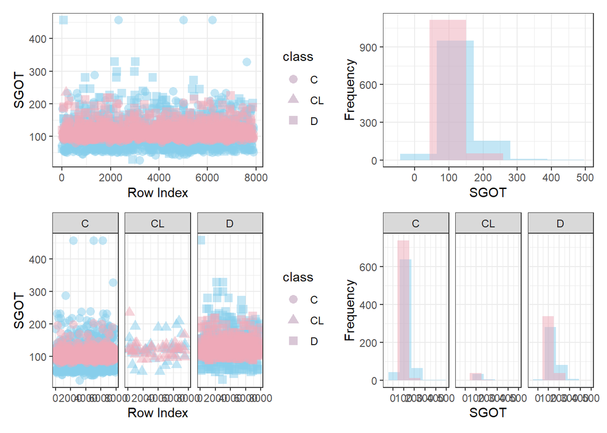

A function to calculate mean square error for different imputation methods (either by class or overall):

```r
imputation_metrics <- function(complete_data, imputed_data, deletion_object, class = NULL){
  #browser()
  if(is.null(class) == TRUE){
    mse <- data.frame(matrix(nrow = 0, ncol = 4))
    colnames(mse) <- c("feature", "MSE", "n_deleted", "range")
    for(ft in colnames(complete_data)){
      indices <- deletion_object[["deleted_indices"]][[ft]]
      if(is.null(indices)){next}
      if(is.numeric(complete_data[[ft]]) == TRUE){
        temp <- data.frame(feature = ft,
                           MSE = mean((complete_data[[ft]][indices] - imputed_data[[ft]][indices])^2), #compute MSE
                           n_deleted = length(indices), #the number of values imputed
                           range = max(c(complete_data[[ft]][indices], #the range of the feature (including values pre-deletion and post-imputation)
                                         imputed_data[[ft]][indices]))
                           - min(c(complete_data[[ft]][indices],
                                   imputed_data[[ft]][indices]))
        )
        mse <- rbind(mse, temp)
      }else{
        temp <- data.frame(feature = ft,
                           MSE = mean((as.numeric(complete_data[[ft]][indices]) -
                              as.numeric(imputed_data[[ft]][indices]))^2),
                           n_deleted = length(indices),
                           range = max(c(as.numeric(complete_data[[ft]][indices]),
                                         as.numeric(imputed_data[[ft]][indices])))
                           - min(c(as.numeric(complete_data[[ft]][indices]),
                                   as.numeric(imputed_data[[ft]][indices])))
        )
        mse <- rbind(mse, temp)
      }
    }
  }else{
    mse <- data.frame(matrix(nrow = 0, ncol = 5))
    colnames(mse) <- c("feature", "class", "MSE", "n_deleted", "range")
    for(ft in colnames(complete_data)){
      indices <- deletion_object[["deleted_indices"]][[ft]]
      if(is.null(indices)){next}
      compare_df <- data.frame(indices = indices,
                               class = complete_data[[class]][indices],
                               complete_data = complete_data[[ft]][indices],
                               imputed_data = imputed_data[[ft]][indices])
      if(is.numeric(compare_df$complete_data) == TRUE){
        for(cl in unique(compare_df$class)){
          fi <- filter(compare_df, class == cl)
          temp <- data.frame(feature = ft,
                             class = cl,
                             MSE = mean((fi$complete_data - fi$imputed_data)^2),
                             n_deleted = length(indices),
                             range = max(c(fi$complete_data, fi$imputed_data))
                             - min(c(fi$complete_data, fi$imputed_data))
          )
          mse <- rbind(mse, temp)
        }
        temp <- data.frame(feature = ft,
                           class = "All",
                           MSE = mean((compare_df$complete_data - compare_df$imputed_data)^2),
                           n_deleted = length(indices),
                           range = max(c(compare_df$complete_data, compare_df$imputed_data))
                           - min(c(compare_df$complete_data, compare_df$imputed_data))
        )
        mse <- rbind(mse, temp)
      }else{
          for(cl in unique(compare_df$class)){
          fi <- filter(compare_df, class == cl)
          temp <- data.frame(feature = ft,
                             class = cl,
                             MSE = mean((as.numeric(fi$complete_data) -
                                           as.numeric(fi$imputed_data))^2),
                             n_deleted = length(indices),
                             range = max(c(as.numeric(fi$complete_data),
                                           as.numeric(fi$imputed_data)))
                             - min(c(as.numeric(fi$complete_data),
                                     as.numeric(fi$imputed_data)))
          )
          mse <- rbind(mse, temp)
        }
        temp <- data.frame(feature = ft,
                           class = "All",
                           MSE = mean((as.numeric(compare_df$complete_data) -
                                         as.numeric(compare_df$imputed_data))^2),
                           n_deleted = length(indices),
                           range = max(c(as.numeric(compare_df$complete_data),
                                         as.numeric(compare_df$imputed_data)))
                           - min(c(as.numeric(compare_df$complete_data),
                                   as.numeric(compare_df$imputed_data)))
        )
        mse <- rbind(mse, temp)
      }
    }
  }
  mse <- mse |>
    mutate(
      scaled_MSE = MSE/range,
      scaled_MSE = ifelse(is.na(scaled_MSE), 0, scaled_MSE) #scale the MSE by the range of the feature for comparability (not a huge deal for comparing between imputation types because they all used the same features)
    )
  cat("\nTotal Scaled MSE:", sum(mse[mse$class != "All", 6]), sep = " ")
  if(is.null(class) == FALSE){
    for(cl in unique(mse$class)){
      if(cl == "All"){next}
      cat("\n     class", cl, ":", sum(mse[mse$class == cl, 6]), sep = " ")
    }
  }
 return(mse) #produces a dataframe of each feature, its MSE overall, and MSE by class
}
```

calculate MSE for features for each imputation method

```r
simple_metrics <- imputation_metrics(train_factor, train_simple_imputed_factor, train_deletion, class = "Status")
```

```
##
## Total Scaled MSE: 4633.893
##      class C : 1219.221
##      class D : 1515.176
##      class CL : 1899.496
```

```r
knn_metrics <- imputation_metrics(train_factor, train_knn_imputed_factor, train_deletion, class = "Status")
```

```
##
## Total Scaled MSE: 4960.688
##      class C : 1375.473
##      class D : 1574.484
##      class CL : 2010.731
```